# Linear Regression

Linear regression is a statistical approach that models the relationship between input features and output.

The input features are called the independent variables, and the output is called a dependent variable.

Our goal here is to predict the value of the output based on the input features by multiplying it with its optimal coefficients.

Some real-life examples of linear regression :

(1) To predict sales of products.

(2) To predict economic growth.

(3) To predict petroleum prices.

(4) To predict the emission of a new car.

(5) Impact of GPA on college admissions.

Simple Linear Regression:

In simple linear regression, we predict the output/dependent variable based on only one input feature. The simple

linear regression is given by:

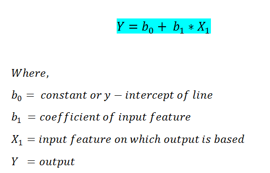

# Our goal is to predict 'co2 emissions' from the value of 'engine size'

Below we are going to implement simple linear regression using the sklearn library in Python.

Step 1. Import required libraries:

```python
# Import required libraries:
import pandas as pd
import numpy as np
import matplotlib.pyplot as plt
from sklearn import linear_model
```

Step 2. Read the CSV file: We check the first five rows of our dataset. In this case, we are using a vehicle model dataset —

```python
# Read the CSV file :
data = pd.read_csv('Fuel.csv')
data.head()
```

|  | MODELYEAR | MAKE | MODEL | VEHICLECLASS | ENGINESIZE | CYLINDERS | TRANSMISSION | FUELTYPE | FUELCONSUMPTION_CITY | FUELCONSUMPTION_HWY | FUELCONSUMPTION_COMB | FUELCONSUMPTION_COMB_MPG | CO2EMISSIONS |
| --- | --- | --- | --- | --- | --- | --- | --- | --- | --- | --- | --- | --- | --- |
| 0 | 2014 | ACURA | ILX | COMPACT | 2.0 | 4 | AS5 | Z | 9.9 | 6.7 | 8.5 | 33 | 196 |
| 1 | 2014 | ACURA | ILX | COMPACT | 2.4 | 4 | M6 | Z | 11.2 | 7.7 | 9.6 | 29 | 221 |
| 2 | 2014 | ACURA | ILX HYBRID | COMPACT | 1.5 | 4 | AV7 | Z | 6.0 | 5.8 | 5.9 | 48 | 136 |
| 3 | 2014 | ACURA | MDX 4WD | SUV - SMALL | 3.5 | 6 | AS6 | Z | 12.7 | 9.1 | 11.1 | 25 | 255 |
| 4 | 2014 | ACURA | RDX AWD | SUV - SMALL | 3.5 | 6 | AS6 | Z | 12.1 | 8.7 | 10.6 | 27 | 244 |

Step 3. Select the features we want to consider in predicting values:

```python
# Let’s select some features to explore more :
data = data[['ENGINESIZE','CO2EMISSIONS']]
```

Step 4. Plot the data

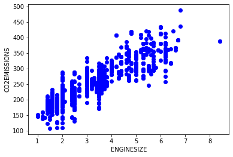

```python
# ENGINESIZE vs CO2EMISSIONS:
plt.scatter(data['ENGINESIZE'] , data['CO2EMISSIONS'] , color='blue')
plt.xlabel('ENGINESIZE')
plt.ylabel('CO2EMISSIONS')
plt.show()
```

Step 5.Divide the data into training and testing data:

To check the accuracy of a model, we are going to divide our data into training and testing datasets.

We will use training data to train our model, and then we will check the accuracy of our model using the testing dataset.

```python
# Generating training and testing data from our data:
# We are using 80% data for training.
train = data[:(int((len(data)*0.8)))]
test = data[(int((len(data)*0.8))):]
```

Step 6. Training our model: Here is how we can train our model and find the coefficients for our best-fit regression line.

```python
# Modeling:
# Using sklearn package to model data :
regr = linear_model.LinearRegression()
train_x = np.array(train[['ENGINESIZE']])
train_y = np.array(train[['CO2EMISSIONS']])
regr.fit(train_x,train_y)
```

```
LinearRegression()
```

Step7. Plot the best fit line: Based on the coefficients, we can plot the best fit line for our dataset.

```python
# The coefficients:
print ('coefficients :' ,regr.coef_) #Slope
print ('Intercept : ',regr.intercept_) #Intercept
```

```
coefficients : [[38.79512384]]
Intercept :  [127.16989951]
```

Step 8. Prediction function: We are going to use a prediction function for our testing dataset.

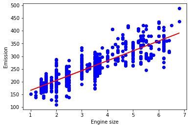

```python
# Plotting the regression line:
plt.scatter(train['ENGINESIZE'], train['CO2EMISSIONS'], color='blue')
plt.plot(train_x, regr.coef_*train_x + regr.intercept_, '-r')
plt.xlabel('Engine size')
plt.ylabel('Emission')
```

Step 9. Predicting co2 emissions: Predicting the values of co2 emissions based on the regression line.

```python
# Predicting values:
# Function for predicting future values :
def get_regression_predictions(input_features,intercept,slope):
 predicted_values = input_features*slope + intercept
 return predicted_values
```

Step 10. Checking accuracy for test data : We can check the accuracy of a model by comparing the actual values with the predicted values in our dataset.

```python
# Predicting emission for future car:
my_engine_size = 3.5
estimatd_emission = get_regression_predictions(my_engine_size,regr.intercept_[0],regr.coef_[0][0])
print ('Estimated Emission :',estimatd_emission)
```

```
Estimated Emission : 262.9528329350172
```

```python
# Checking various accuracy:
from sklearn.metrics import r2_score
test_x = np.array(test[['ENGINESIZE']])
test_y = np.array(test[['CO2EMISSIONS']])
test_y_ = regr.predict(test_x)
```

```python
print('Mean absolute error: %.2f' % np.mean(np.absolute(test_y_ - test_y)))
print('Mean sum of squares (MSE): %.2f' % np.mean((test_y_ - test_y) ** 2))
print('R2-score: %.2f' % r2_score(test_y_ , test_y) )
```

```
Mean absolute error: 20.60
Mean sum of squares (MSE): 746.45
R2-score: 0.71
```